# Data Science Capstone

Yohannes Zerfu

November 5, 2014

## Introduction

This paper is presented as part of a capstone project, which is to build a predictive model in the natural languauge processing.

### Getting the Data

The plan on getting the data is to read all the data first form a corpus called HC Corpora (www.corpora.heliohost.org). The Data is downloaded from https://d396qusza40orc.cloudfront.net/dsscapstone/dataset/Coursera-SwiftKey.zip For this step of exploratory analysis, we have selected a subset of the data provided, 100000 lines from each documents.

```r
tweetDoc<-readLines("./en_US/en_US.twitter.txt", 100000,encoding="UTF-8", warn=F)
blogsDoc<- readLines("./en_US/en_US.blogs.txt", 100000, encoding="UTF-8")
newsDoc<- readLines("./en_US/en_US.news.txt",  100000, encoding="UTF-8")
```

After reading the subset of the documents, they are stored in train folder of my machine to build a corpus.

Then we prepare a courpus containing all three files of 100000 rows each.

```r
dirname <- file.path(".", "train")
dirsource<-DirSource(dirname)
files <- Corpus(dirsource, readerControl=list(reader=readPlain))
```

### Basic info of the three data.

The tweet, blogs and news documents have 100000 lines each with 6.6, 22.1 and 19.4 MB of data respectively. The number of words in each file is shown blelow. As it can be seen from the following table, the percentage of unique words used in twitter data is 6.5%, news is 3.7% and blogs is 3.7%.

```
##                      stat      twitter         news        blogs
## 1 Number of sampled words 1.315950e+06 3.497393e+06 4.189671e+06
## 2  Number of Unique words 8.548700e+04 1.281850e+05 1.548020e+05
## 3    Percentage of Unique 6.496219e+00 3.665159e+00 3.694849e+00
```

### Looking into the Corpus:

In these three documents there are several words which are not going to help us in making our predictive model. Therefore we need to perform some pre-processing of the text data to prepare for the text analysis. Example preprocessing include converting the text to lower case, removing numbers and punctuation, removing stop words, stemming and identifying synonyms. The basic transformations are all available within tm package. The function tm_map() is used to apply one of these transformations across all documents within a corpus. Other transformations can be implemented using R functions and wrapped within gsub() to create a function that can be passed through to tm_map(). In the following sections we will apply each of the transformations, one-by-one, to remove un-wanted characters from the text.

```r
files <- tm_map(files, stripWhitespace)
files <- tm_map(files, removeNumbers)
files <- tm_map(files, tolower)
files <- tm_map(files, removePunctuation)
files <- tm_map(files, removeWords, stopwords("english"))
files <- tm_map(files, function(x) gsub('[])(;:#%$^*\\~{}[&+=@/"`|<>_]+', "", x))
```

After processing the data, we perform unigram tokenizer to see the data clearly and prepare for pridiction model, we have removed sparse terms from our data for couple of reasons. the first reason is that those sparse words that happened once or twice in our data will have a little or insignificant effect on our prediction model. The second reason is to safe a memory space and increase speed.

The the top 15 most frequent terms in the three sampled documents are:

```
##   said   will    one   just   like    can   time    get    new    now
##  29461  27375  25409  22703  20820  20671  18294  16788  15802  13836
## people   dont   also   good    day
##  13380  12882  12661  12471  12389
```

here is correlation plot

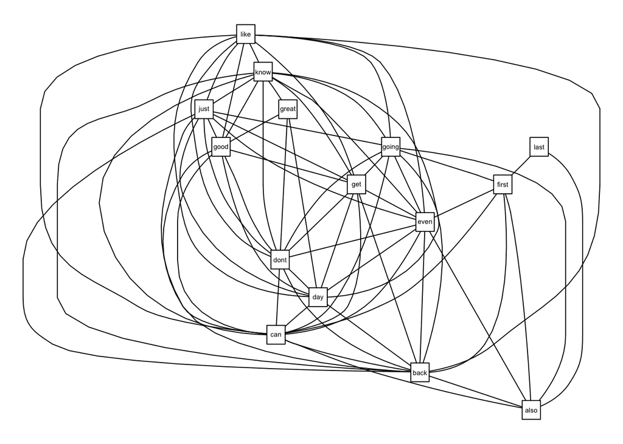

Now we plot the frequency of theose words which occur atleaset 8000 times

[figure not shown]

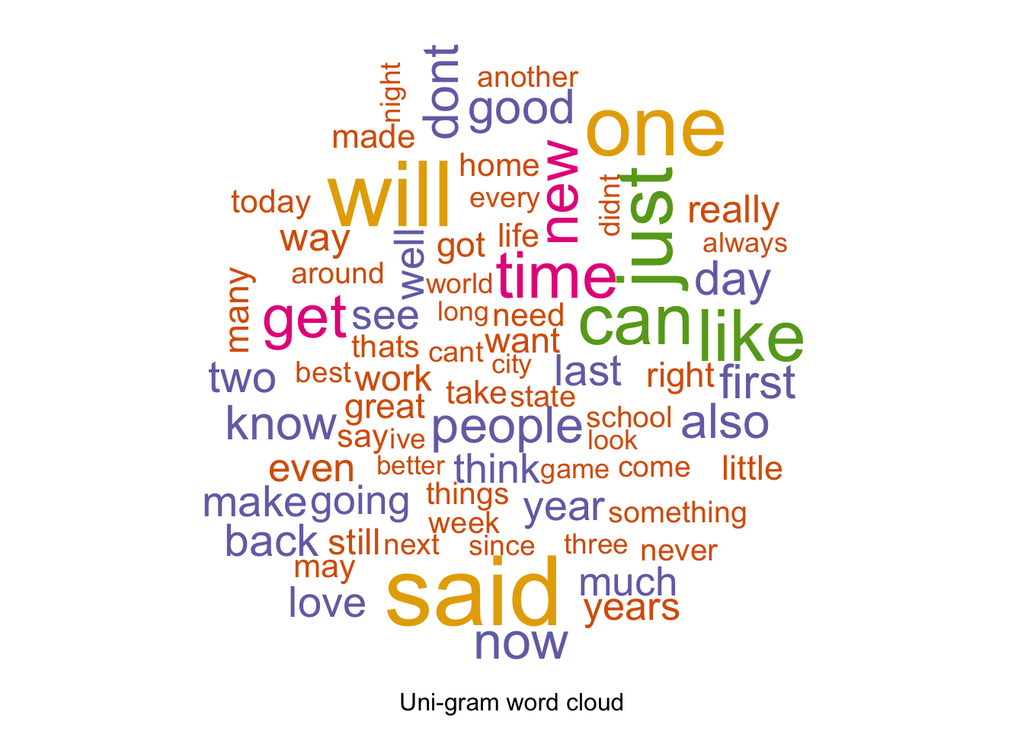

I have also prepared three gram tokenizer to build the predictive model. The reason why I am not considering a bi-gram tokenizer is that, in my opinion it will be very hard for the model to predict the next word based on just one previous word (I may revisit this latr)

```
##          new york city          cant wait see          two years ago
##                    225                    188                    163
##            let us know         im pretty sure president barack obama
##                    158                    131                    129
##         new york times       first time since         happy new year
##                    126                     95                     93
##        three years ago           feel like im          two weeks ago
##                     82                     81                     81
##     im looking forward        will take place
##                     79                     78
```

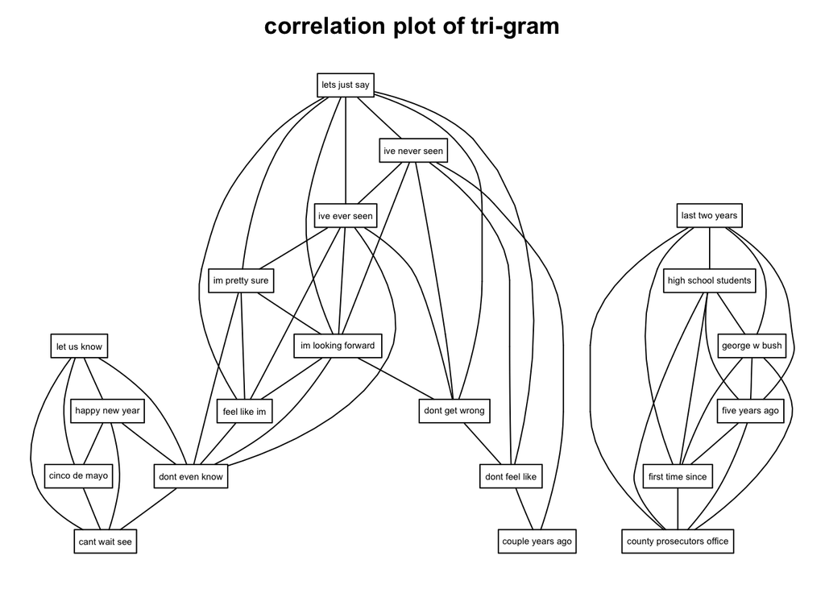

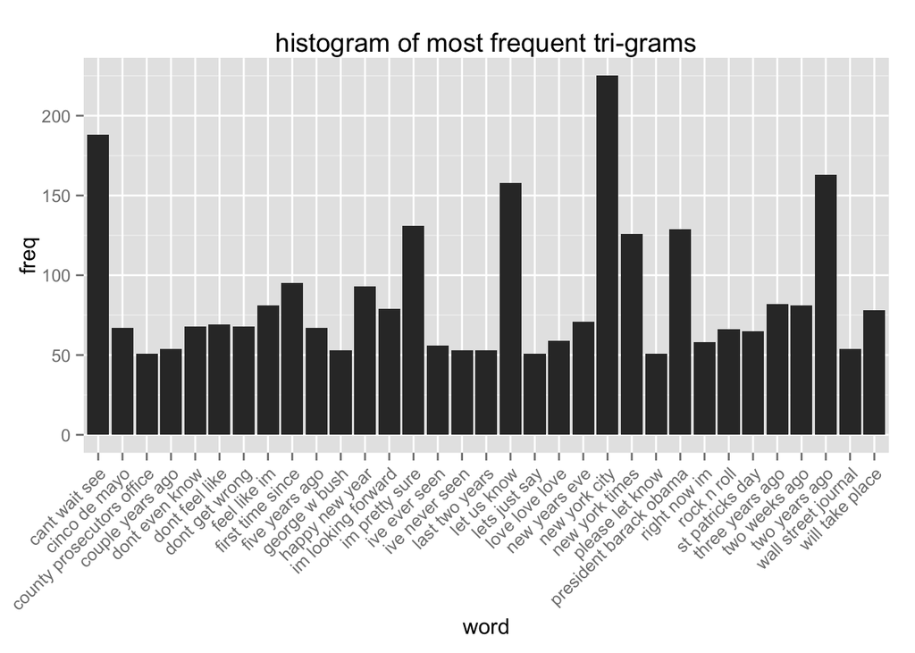

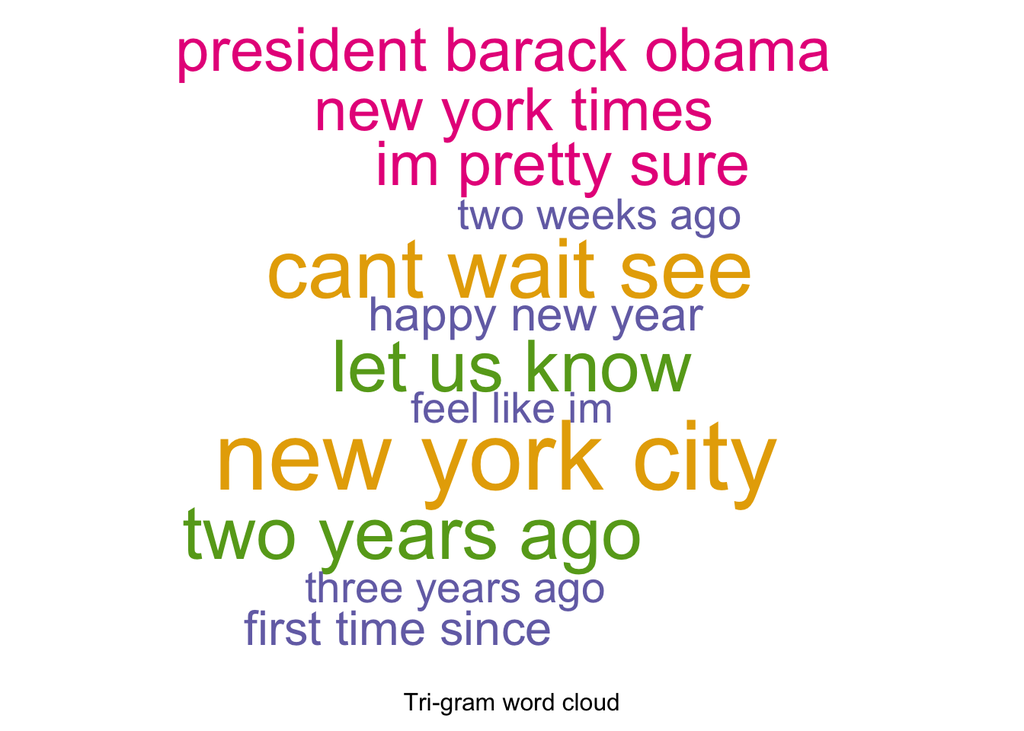

### Conclusion

As it is shown above I have started a way to developing a predictive model. I will be considering Markov Chains model, esimating conditional probablities of a word given the previous word, smoothig the probablities to avoid a zero probablity as i will not have all combinantions of the the words in english language in my database. A shiny app will be developed which will be developed based on the predictive model, which will predict the next word.